# uavimg Demo

March 3, 2018

This is a demo of the `uavimg` package for R. For installation instructions, see http://github.com/ucanr-igis/uavimg.

### Load packages

First we load the package.

```r
library(uavimg)
```

### See which cameras are supported

To see which cameras the package knows about, user the *cameras()* function. If your camera is not listed, contact the package author to have it added.

```r
cameras()
```

```
## [1] "DJI ZenMuse X5"      "DJI ZenMuse X3"      "DJI Phantom 3S"
## [4] "Parrot Sequoia RGB"  "Parrot Sequoia mono" "Hero4 Black/Silver"
## [7] "DJI ZenMuse X3"
```

### Get the directory with the images

Find a directory that has images from a single flight. In this example, we’ll examine images taken from a ZenMuse X5 RGB camera onboard a DJI Matrice 100.

```r
img_dir <- "/Pix4D/El_Dorado_MG/Sherwood/Data/20171210_X5/Flt01_1253_1305_30m_nadir"

## Verify it exists and see what's there
file.exists(img_dir)
```

```
## [1] TRUE
```

```r
str(list.files(img_dir, "JPG$"))
```

```
##  chr [1:366] "DJI_0001.JPG" "DJI_0002.JPG" "DJI_0003.JPG" ...
```

### Process Images

Process the folder of images by feeding it into the **uavimg_info()** function. This returns a named list with three elements.

```r
flt01 <- uavimg_info(img_dir, shp_save=FALSE)
```

```
## Looking for image files in /Pix4D/El_Dorado_MG/Sherwood/Data/20171210_X5/Flt01_1253_1305_30m_nadir
## Found DJI ZenMuse X5
## Running exiftool...Done.
## Creating footprints...Done.
## Computing forward overlap...Done.
## All done.
```

### Produce a Report

To create a HTML report of the images, use the **uavimg_report()** function.

```r
uavimg_report(flt01)
```

### Explore the images

The three elements in the returned list are named *pts* (containing a SpatialPointsDataFrame with the image centroids), *fp* (SpatialPolygonsDataFrame contained the estimaged image footrpints), and *img_dir* (directory). *pts* and *fp* are both projected in UTM.

```r
class(flt01$pts)
```

```
## [1] "SpatialPointsDataFrame"
## attr(,"package")
## [1] "sp"
```

```r
class(flt01$fp)
```

```
## [1] "SpatialPolygonsDataFrame"
## attr(,"package")
## [1] "sp"
```

### Plot image locations

We can plot the image locations.

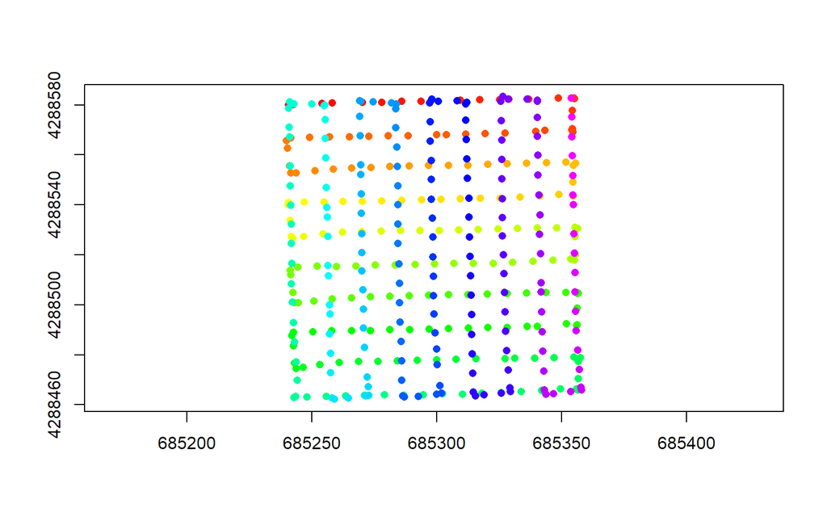

```r
num_pts <- nrow(flt01$pts@data)
plot(flt01$pts, axes=TRUE, asp=1, pch=16, col=rainbow(num_pts, end=5/6))
```

## Inspect attributes

To see the fields in the ‘attribute table’ of the image locations:

```r
names(flt01$pts@data)
```

```
##  [1] "img_fn"     "file_name"  "filetype"   "date_time"  "gps_lat"
##  [6] "gps_long"   "gps_alt"    "make"       "model"      "focal_len"
## [11] "img_width"  "img_height" "yaw"        "alt_agl"    "sens_wdth"
## [16] "sens_hght"  "gsd"        "fp_width"   "fp_height"
```

To get a summary of one of those, for eample *gsd* (which is measured in cm/pix):

```r
summary(flt01$pts@data$gsd)
```

```
##    Min. 1st Qu.  Median    Mean 3rd Qu.    Max.
##  0.7333  0.7459  0.7509  0.7496  0.7534  0.7684
```

### Plot the footprints

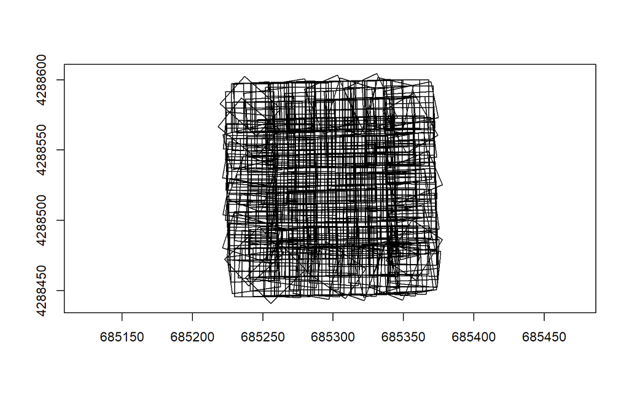

```r
plot(flt01$fp, axes=TRUE)
```

How horrible. Let’s just plot a few. We’ll make the outlines dotted to remind ourselves that the footprints are estimated.

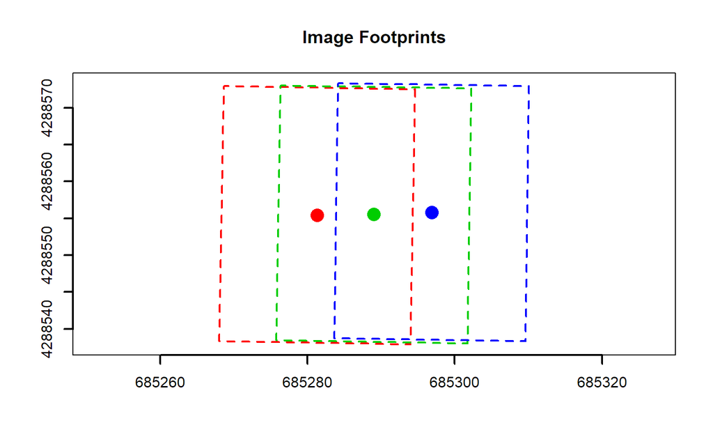

```r
idx <- 45:47
plot(flt01$fp[idx,], axes=TRUE, border=palette()[2:4], lwd=2, lty=2, main="Image Footprints")
plot(flt01$pts[idx,], add=TRUE, pch=16, col=palette()[2:4], cex=2)
```

The script computes the percent forward overlap. Let’s examine the distribution of this value:

```r
summary(flt01$fp@data$fwd_ovrlap)
```

```
##    Min. 1st Qu.  Median    Mean 3rd Qu.    Max.    NA's
##  0.5258  0.6918  0.6981  0.7171  0.7483  0.9375       1
```

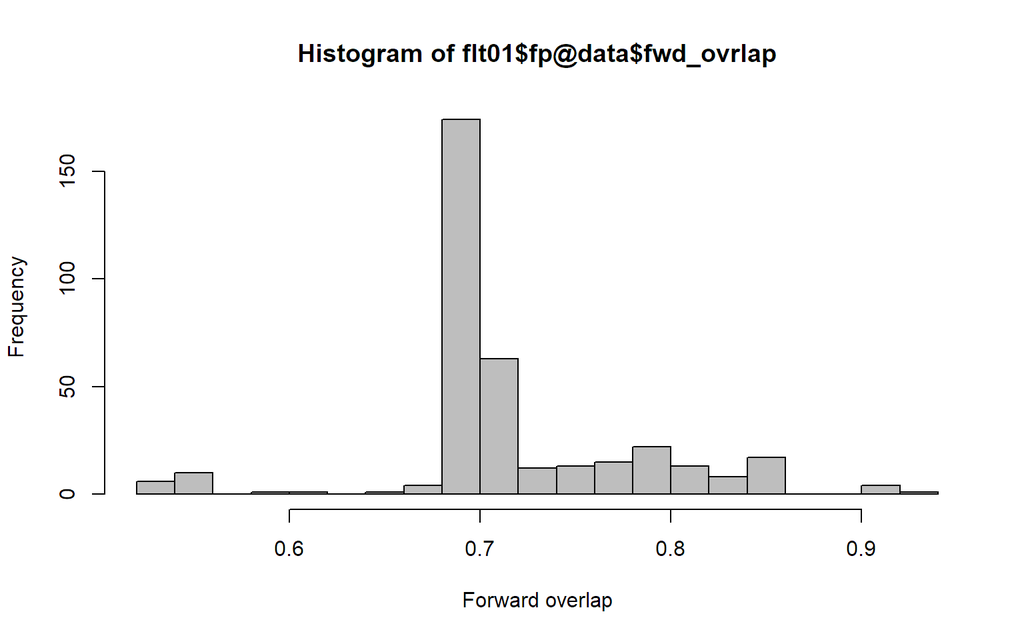

```r
hist(flt01$fp@data$fwd_ovrlap, breaks = 15, col="grey", xlab="Forward overlap")
```

It looks like this flight was flown with 70% overlap. A few images have higher overlap, perhaps because the drone was turning or slowed down. We can color them by the amount of forward overlap:

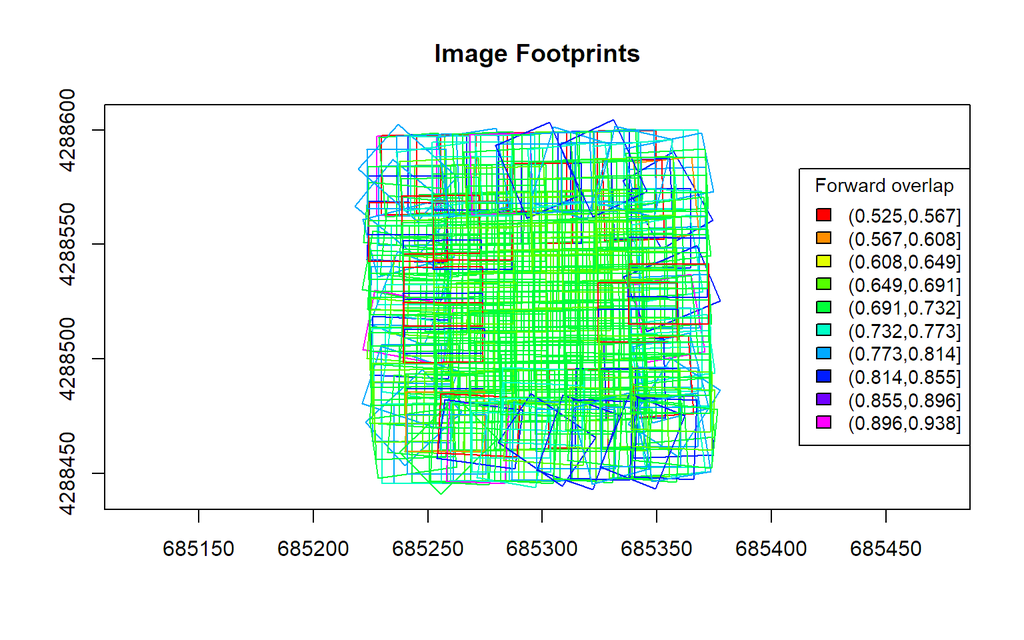

```r
num_breaks <- 10
fwdovr_factor <- cut(flt01$fp@data$fwd_ovrlap, breaks=num_breaks)
col_ramp <- rainbow(num_breaks, end=5/6)
plot(flt01$fp, axes=TRUE, border=col_ramp[as.numeric(fwdovr_factor)], main="Image Footprints")
legend("right", legend=levels(fwdovr_factor), fill=col_ramp, bg="white", cex=0.9, title="Forward overlap")
```

### Example 2

The example below is similar to the first, but here we’ll examine the RGB images from a Parrot Sequoia onboard a 3DR Solo. Unlike the X5, the Sequoia doesn’t record relative altitude, so we’ll have to supply the flight elevation manually. We can use a convenience function `ft2m()` to convert feet to meters.

```r
img_dir <- "/Pix4D/HREC/Watershed2/Data/2017-01-17_Seq/Flight01_1321_1328_400ft/RGB"
file.exists(img_dir)
```

```
## [1] TRUE
```

```r
flt02 <- uavimg_info(img_dir, shp_save=TRUE, alt_agl = ft2m(400))
```

[output not shown]

```
## Looking for image files in /Pix4D/HREC/Watershed2/Data/2017-01-17_Seq/Flight01_1321_1328_400ft/RGB
## Found Parrot Sequoia RGB
## Running exiftool...Done.
## Creating footprints...Done.
## Computing forward overlap...Done.
## Saving Shapefiles to /Pix4D/HREC/Watershed2/Data/2017-01-17_Seq/Flight01_1321_1328_400ft/RGB
##  - img_ctr.shp
##  - img_fp.shp
## All done.
```

Let’s plot the centroids.

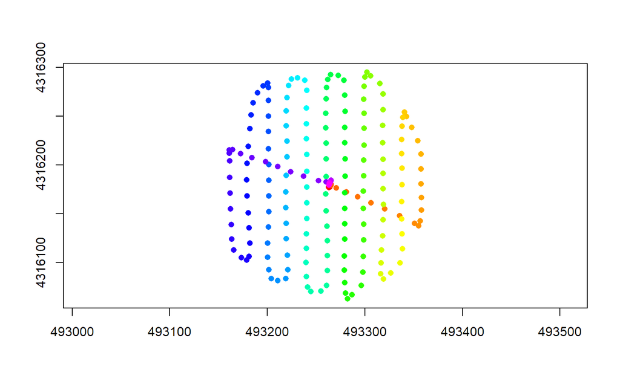

```r
num_pts <- nrow(flt02$pts@data)
plot(flt02$pts, axes=TRUE, asp=1, pch=16, col=rainbow(num_pts, end=5/6))
```

Inspect a few of the footprints and the amount of forward overlap.

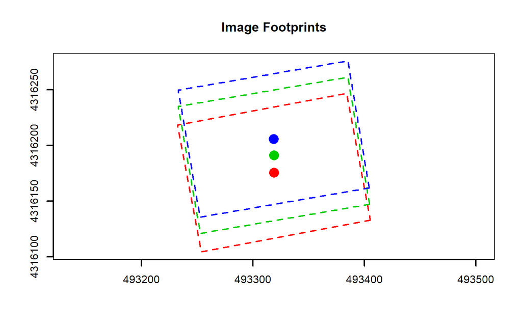

```r
idx <- 55:57
plot(flt02$fp[idx,], axes=TRUE, border=palette()[2:4], lty=2, lwd=2, main="Image Footprints")
plot(flt02$pts[idx,], add=TRUE, pch=16, col=palette()[2:4], cex=2)
```

```r
flt02$fp@data[idx,"fwd_ovrlap"]
```

```
## [1] 0.8510997 0.8625896 0.8395714
```

It looks like this mission was flown with 85% forward overlap. Let’s look at the distribution of forward overlap for all the images.

```r
summary(flt02$fp@data$fwd_ovrlap)
```

```
##    Min. 1st Qu.  Median    Mean 3rd Qu.    Max.    NA's
##  0.7511  0.8315  0.8479  0.8631  0.8849  0.9984       1
```